# ACMG-ClinVar Penetrance RMarkdown

James Diao, under the supervision of Arjun Manrai

October 28, 2016

Abstract

Here, we examine ExAC and the 1000 Genomes Project to investigate the distribution of pathogenic variants across diverse populations. Pathogenic variants were found to be distributed unevenly across ancestral groups, with incidental findings inflated relative to empirical disease prevalences. Quantitative risk estimates were derived by modeling penetrance as a function of disease prevalence, allele frequency, and allelic heterogeneity. Plausible ranges for these parameters were estimated from ExAC, the 1000 Genomes cohort, and the medical literature. Under the most generous assumptions, penetrance estimates for the majority of diseases fall under 50%, with many under 5%. We propose the described model of penetrance as a quantitative framework for evaluating, comparing, and updating clinical interpretations of pathogenic variants.

**Working Directory**: /Users/jamesdiao/Documents/Kohane_Lab/2016-paper-ACMG-penetrance

\newpage

# 1 Download, Transform, and Load Data

## 1.1 Collect ACMG Gene Panel

http://www.ncbi.nlm.nih.gov/clinvar/docs/acmg/

```
## Processed Table from ACMG Website 64 x 4 (selected rows):
```

|  | Disease_Name | Disease_MIM | Gene_Name | Gene_MIM |
| --- | --- | --- | --- | --- |
| **A1** | Adenomatous polyposis coli | 175100 | APC | 611731 |
| **A2** | Aortic aneurysm, familial thoracic 4 | 132900 | MYH11 | 160745 |
| **A5** | Arrhythmogenic right ventricular cardiomyopathy, type 5 | 604400 | TMEM43 | 612048 |
| **A10** | Breast-ovarian cancer, familial 1 | 604370 | BRCA1 | 113705 |
| **A11** | Breast-ovarian cancer, familial 2 | 612555 | BRCA2 | 600185 |
| **A12** | Brugada syndrome 1 | 601144 | SCN5A | 600163 |
| **A13** | Catecholaminergic polymorphic ventricular tachycardia | 604772 | RYR2 | 180902 |
| **A14** | Dilated cardiomyopathy 1A | 115200 | LMNA | 150330 |
| **A16** | Ehlers-Danlos syndrome, type 4 | 130050 | COL3A1 | 120180 |
| **A17** | Fabry’s disease | 301500 | GLA | 300644 |
| **A18** | Familial hypercholesterolemia | 143890 | APOB | 107730 |
| **A20** | Familial hypertrophic cardiomyopathy 1 | 192600 | MYH7 | 160760 |
| **A28** | Familial medullary thyroid carcinoma | 155240 | RET | 164761 |
| **A30** | Left ventricular noncompaction 6 | 601494 | TNNT2 | 191045 |
| **A31** | Li-Fraumeni syndrome 1 | 151623 | TP53 | 191170 |
| **A32** | Loeys-Dietz syndrome type 1A | 609192 | TGFBR1 | 190181 |
| **A37** | Long QT syndrome 1 | 192500 | KCNQ1 | 607542 |
| **A40** | Lynch syndrome | 120435 | MLH1 | 120436 |
| **A44** | Malignant hyperthermia | 145600 | RYR1 | 180901 |
| **A46** | Marfan’s syndrome | 154700 | FBN1 | 134797 |
| **A48** | Multiple endocrine neoplasia, type 1 | 131100 | MEN1 | 613733 |
| **A51** | MYH-associated polyposis | 608456 | MUTYH | 604933 |
| **A52** | Neurofibromatosis, type 2 | 101000 | NF2 | 607379 |
| **A53** | Paragangliomas 1 | 168000 | SDHD | 602690 |
| **A57** | Peutz-Jeghers syndrome | 175200 | STK11 | 602216 |
| **A58** | Pilomatrixoma | 132600 | MUTYH | 604933 |
| **A59** | PTEN hamartoma tumor syndrome | 153480 | PTEN | 601728 |
| **A60** | Retinoblastoma | 180200 | RB1 | 614041 |
| **A61** | Tuberous sclerosis 1 | 191100 | TSC1 | 605284 |
| **A63** | Von Hippel-Lindau syndrome | 193300 | VHL | 608537 |
| **A64** | Wilms’ tumor | 194070 | WT1 | 607102 |

```
## ACMG-56 Genes:
```

```
##  [1] APC     MYH11   ACTA2   MYLK    TMEM43  DSP     PKP2    DSG2
##  [9] DSC2    BRCA1   BRCA2   SCN5A   RYR2    LMNA    MYBPC3  COL3A1
## [17] GLA     APOB    LDLR    MYH7    TPM1    PRKAG2  TNNI3   MYL3
## [25] MYL2    ACTC1   RET     PCSK9   TNNT2   TP53    TGFBR1  TGFBR2
## [33] SMAD3   KCNQ1   KCNH2   MLH1    MSH2    MSH6    PMS2    RYR1
## [41] CACNA1S FBN1    MEN1    MUTYH   NF2     SDHD    SDHAF2  SDHC
## [49] SDHB    STK11   PTEN    RB1     TSC1    TSC2    VHL     WT1
```

## 1.2 Download ClinVar VCF

ftp://ftp.ncbi.nlm.nih.gov/pub/clinvar/vcf_GRCh37/clinvar.vcf.gz  
ClinVar is the central repository for variant interpretations. Relevant information from the VCF includes:  
(a) CLNSIG = “Variant Clinical Significance, 0 - Uncertain, 1 - Not provided, 2 - Benign, 3 - Likely benign,  
4 - Likely pathogenic, 5 - Pathogenic, 6 - Drug response, 7 - Histocompatibility, 255 - Other”  
(b) CLNDBN = “Variant disease name”  
(c) CLNDSDBID = “Variant disease database ID”  
(d) INTERP = Pathogenicity (likely pathogenic or pathogenic; CLNSIG = 4 or 5)

```
## Processed ClinVar data frame 117420 x 14 (selected rows/columns):
```

| VAR_ID | CHROM | POS | ID | REF | ALT | CLNSIG |
| --- | --- | --- | --- | --- | --- | --- |
| 1_955597_G_T | 1 | 955597 | rs115173026 | G | T | 2 |
| 1_955619_G_C | 1 | 955619 | rs201073369 | G | C | 255 |
| 1_957605_G_A | 1 | 957605 | rs756623659 | G | A | 5 |

Table continues below

| CLNDBN | CLNDSDBID | INTERP |
| --- | --- | --- |
| not_specified | CN169374 | FALSE |
| not_specified | CN169374 | FALSE |
| Congenital_myasthenic_syndrome | C0751882:ORPHA590 | TRUE |

## 1.3 Download 1000 Genomes VCFs

ftp://ftp.1000genomes.ebi.ac.uk/vol1/ftp/release/20130502/ALL.[chrom].phase3_[version].20130502.genotypes.vcf.gz  
Downloaded 1000 Genomes VCFs are saved in: /Users/jamesdiao/Documents/Kohane_Lab/2016-paper-ACMG-penetrance/1000G/

```
## Download report: region and successes: 56 x 6 (selected rows):
```

| gene | name | chrom | start | end | downloaded |
| --- | --- | --- | --- | --- | --- |
| APC | NM_001127511 | 5 | 1.12e+08 | 112181936 | TRUE |
| MYH11 | NM_001040113 | 16 | 15796991 | 15950887 | TRUE |
| ACTA2 | NM_001141945 | 10 | 90694830 | 90751154 | TRUE |
| MYLK | NM_001321309 | 3 | 123331142 | 123603149 | TRUE |
| TMEM43 | NM_024334 | 3 | 14166439 | 14185180 | TRUE |

```
## File saved as download_output.txt in Supplementary_Files
```

\newpage

## 1.4 Collect 1000 Genomes Phase 3 Populations Map

This will allow us to assign genotypes from the 1000 Genomes VCF to ancestral groups.  
From: ftp://ftp.1000genomes.ebi.ac.uk/vol1/ftp/release/20130502/integrated_call_samples_v3.20130502.ALL.panel

```
## Phase 3 Populations Map Table: 2504 x 4 (selected rows)
```

| sample | pop | super_pop | gender |
| --- | --- | --- | --- |
| NA18507 | YRI | AFR | male |
| HG00640 | PUR | AMR | male |
| HG01488 | CLM | AMR | male |
| HG00403 | CHS | EAS | male |
| NA12400 | CEU | EUR | female |
| HG00121 | GBR | EUR | female |
| HG03916 | BEB | SAS | female |
| NA21107 | GIH | SAS | male |
| HG03625 | PJL | SAS | female |
| HG03838 | STU | SAS | female |

```
## Population Distribution
```

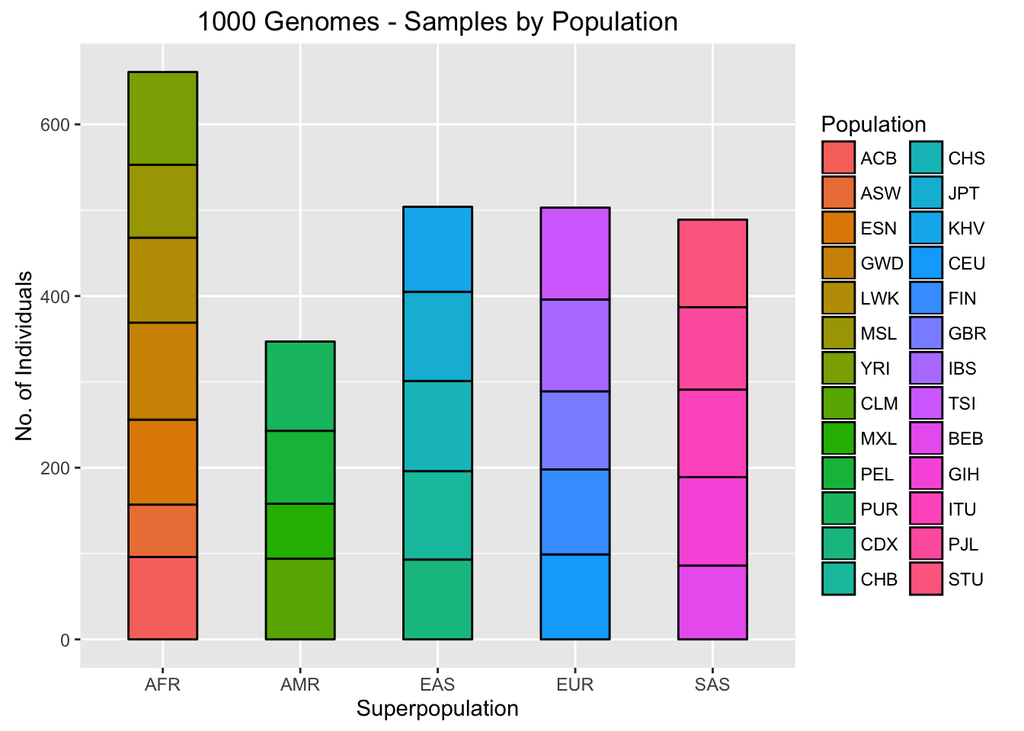

\newpage

## 1.5 Import and Process 1000 Genomes VCFs

1. Unnest the data frames to 1 row per variant_ID key (CHROM_POSITION_REF_ALT).
2. Remove all insertions, deletions, CNV, etc, and keep only missense variants (1 REF, 1 ALT)
3. For 1000 Genomes: convert genomes to allele counts. For example: (0|1) becomes 1, (1|1) becomes 2.  
   Multiple alleles are unnested into multiple counts. For example: (0|2) becomes 0 for the first allele (no 1s) and 1 for the second allele (one 2).

```
## Processed 1000 Genomes VCFs: 139335 x 2516 (selected rows/columns):
```

| GENE | AF_1000G | VAR_ID | CHROM | POS | ID | REF | ALT |
| --- | --- | --- | --- | --- | --- | --- | --- |
| APC | 0.0001997 | 5_112043211_A_G | 5 | 1.12e+08 | rs554351451 | A | G |
| APC | 0.0001997 | 5_112043231_G_A | 5 | 1.12e+08 | rs575784409 | G | A |
| APC | 0.005391 | 5_112043234_C_T | 5 | 1.12e+08 | rs115658307 | C | T |
| APC | 0.0001997 | 5_112043252_G_A | 5 | 1.12e+08 | rs558562104 | G | A |
| APC | 0.008786 | 5_112043263_C_T | 5 | 1.12e+08 | rs138386816 | C | T |

Table continues below

| HG00096 | HG00097 | HG00099 | HG00100 | HG00101 | HG00102 |
| --- | --- | --- | --- | --- | --- |
| 0 | 0 | 0 | 0 | 0 | 0 |
| 0 | 0 | 0 | 0 | 0 | 0 |
| 0 | 0 | 0 | 0 | 0 | 0 |
| 0 | 0 | 0 | 0 | 0 | 0 |
| 0 | 0 | 0 | 0 | 0 | 0 |

## 1.6 Import and Process ExAC VCFs

1. Unnest the data frames to 1 row per variant_ID key (CHROM_POSITION_REF_ALT).
2. Remove all insertions, deletions, CNV, etc, and keep only missense variants (1 REF, 1 ALT)
3. Collect superpopulation-level allele frequencies:  
   African = AFR, Latino = AMR, European (Finnish + Non-Finnish) = EUR, East.Asian = EAS, South.Asian = SAS.

```
## Processed ExAC VCFs: 58873 x 45 (selected rows/columns):
```

| GENE | AF_EXAC | AF_EXAC_AFR | AF_EXAC_AMR | AF_EXAC_EAS | AF_EXAC_EUR |
| --- | --- | --- | --- | --- | --- |
| APC | 8.13e-05 | 0 | 0 | 0 | 0 |
| APC | 8.131e-05 | 0 | 0 | 0 | 0 |
| APC | 0.1112 | 0.07979 | 0.1022 | 0 | 0.1063 |
| APC | 8.131e-05 | 0 | 0 | 0 | 0 |
| APC | 8.134e-05 | 0 | 0 | 0 | 0 |

Table continues below

| AF_EXAC_SAS | VAR_ID | CHROM | POS | ID | REF | ALT |
| --- | --- | --- | --- | --- | --- | --- |
| 0.0001313 | 5_112043365_G_C | 5 | 1.12e+08 | . | G | C |
| 0.0001313 | 5_112043382_A_G | 5 | 1.12e+08 | . | A | G |
| 0.1185 | 5_112043384_T_G | 5 | 1.12e+08 | rs78429131 | T | G |
| 0.0001313 | 5_112043392_C_T | 5 | 1.12e+08 | . | C | T |
| 0.0001313 | 5_112043412_C_G | 5 | 1.12e+08 | . | C | G |

\newpage

## 1.7 Merge ClinVar with 1000 Genomes and ExAC

```
## Breakdown of ClinVar Variants
```

| Subset_ClinVar | Number_of_Variants |
| --- | --- |
| Total ClinVar | 117420 |
| LP/P-ClinVar | 33633 |
| LP/P-ClinVar & ACMG | 6971 |
| LP/P-ClinVar & ACMG & ExAC | 964 |
| LP/P-ClinVar & ACMG & 1000 Genomes | 147 |

```
## Breakdown of ACMG-1000 Genomes Variants
```

| Subset_1000_Genomes | Number_of_Variants |
| --- | --- |
| Total 1000_Genomes & ACMG | 139335 |
| 1000_Genomes & ACMG & ClinVar | 4339 |
| 1000_Genomes & ACMG & LP/P-ClinVar | 147 |

```
## Breakdown of ACMG-ExAC Variants
```

| Subset_ExAC | Number_of_Variants |
| --- | --- |
| Total ExAC & ACMG | 58873 |
| ExAC & ACMG & ClinVar | 9347 |
| ExAC & ACMG & LP/P-ClinVar | 964 |

\newpage

## 1.8 Comparison with ClinVar Browser Query Results

`clinvar_query.txt` contains all results matched by the search query: “(APC[GENE] OR MYH11[GENE]… OR WT1[GENE]) AND (clinsig_pathogenic[prop] OR clinsig_likely_pathogenic[prop])” from the ClinVar website. The exact query is saved in /Supplementary_Files/query_input.txt  
This presents another way of collecting data from ClinVar.

Intermediate step: convert hg38 locations to hg19 using the Batch Coordinate Conversion tool (liftOver) from UCSC Genome Browser Utilities.

```
## ClinVar Query Results Table (substitutions only): 6714 x 13 (selected rows/columns)
```

| VAR_ID | Gene(s) | Condition(s) | Frequency |
| --- | --- | --- | --- |
| X_100652891_C_G | GLA | Fabry disease | GMAF:0.00050(G) |
| 11_47374186_C_G | MYBPC3 | Primary familial hypertrophic cardiomyopathy | GMAF:0.00020(G) |
| 11_47355233_C_G | MYBPC3 | Familial hypertrophic cardiomyopathy 4 | GMAF:0.00020(G) |
| 11_47364162_C_G | MYBPC3 | Familial hypertrophic cardiomyopathy 4 | GMAF:0.00020(G) |
| 14_23886482_G_C | MYH7 | not specified | GMAF:0.00020(C) |
| 14_23893148_C_G | MYH7 | Primary dilated cardiomyopathy | GO-ESP:0.00046(G) |
| 1_17355075_A_T | SDHB | Gastrointestinal stromal tumor | GMAF:0.00120(T) |
| 1_17380507_G_C | SDHB | Cowden syndrome 2 | GO-ESP:0.01323(C) |

```
## Breakdown of ClinVar Query Results Table:
```

| Subset | Number_of_Variants |
| --- | --- |
| Initial Count | 12525 |
| Filter Substitutions (N>N’) | 6732 |
| Filter Coupling/Bad-Locations | 6714 |
| In ClinVar VCF | 508 |
| In LP/P-ClinVar VCF | 504 |
| ^ & ACMG & ExAC | 48 |
| ^ & ACMG & 1000 Genomes | 9 |
| ^ & ACMG & ExAC & 1000 Genomes | 8 |

[output not shown]

\newpage

# 2 Plot Summary Statistics Across Populations

## 2.1 Overall Non-Reference Sites

#### 2.1.0.1 For 1000 Genomes

Each individual has $n$ non-reference sites, which can be found by counting. The mean number is computed for each population.

Ex: the genotype of 3 variants in 3 people looks like this:

|  | HG00097 | HG00099 | HG00100 |
| --- | --- | --- | --- |
| **Variant 1** | 0 | 2 | 1 |
| **Variant 2** | 0 | 0 | 1 |
| **Variant 3** | 0 | 0 | 1 |

Count the number of non-reference sites per individual:

| HG00097 | HG00099 | HG00100 |
| --- | --- | --- |
| 0 | 1 | 3 |

```
## Mean = 1.33
```

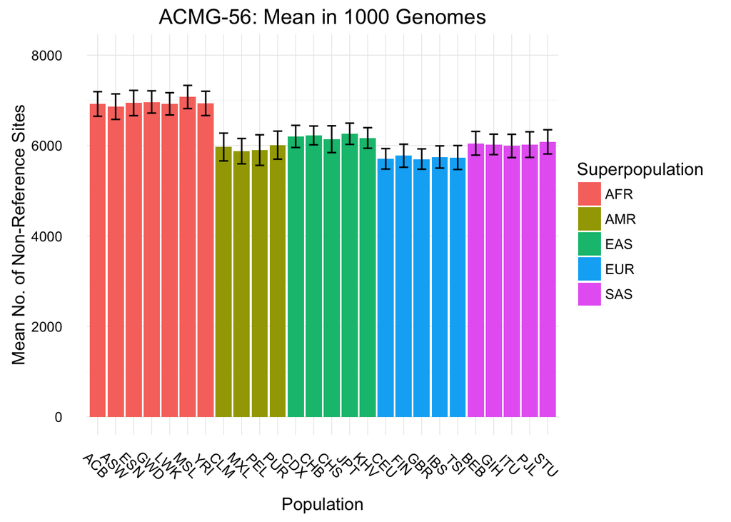

Note: the error bars denote standard deviation, not standard error.

\newpage

#### 2.1.0.2 For ExAC

The mean number of non-reference sites is $E(V)$, where $V = \sum_{i=1}^n v_i$ is the number of non-reference sites at all variant positions $v_1$ through $v_n$.

At each variant site, the probability of having at least 1 non-reference allele is $P(v_i) = P(v_{i,a} \cup v_{i,b})$, where $a$ and $b$ indicate the 1st and 2nd allele at each site.

If the two alleles are independent, $P(v_{i,a} \cup v_{i,b})$ = $1-(1-P(v_{i,a}))(1-P(v_{i,b})) = 1-(1-AF(v_i))^2$

If all variants are independent, $E(V) = \sum_{i=1}^n 1-(1-AF(v_i))^2$ for any set of allele frequencies.

Ex: the allele frequencies of 3 variants across the 5 superpopulations looks like this:

|  | AFR | AMR | EAS | EUR | SAS |
| --- | --- | --- | --- | --- | --- |
| **Variant 1** | 0.1 | 0.2 | 0 | 0 | 0.3 |
| **Variant 2** | 0.2 | 0 | 0.3 | 0 | 0.1 |

The probability of having at least 1 non-reference site at each variant - (0|1) (1|0) or (1|1) is given by $1-(1-AF)^2$. Note that this is approximately $2*AF$ when $AF$ is small:

|  | AFR | AMR | EAS | EUR | SAS |
| --- | --- | --- | --- | --- | --- |
| **Variant 1** | 0.19 | 0.36 | 0 | 0 | 0.51 |
| **Variant 2** | 0.36 | 0 | 0.51 | 0 | 0.19 |

By linearity of expectation, the expected (mean) number of non-reference sites is $\sum E(V_i) = \sum (columns)$.

| AFR | AMR | EAS | EUR | SAS |
| --- | --- | --- | --- | --- |
| 0.55 | 0.36 | 0.51 | 0 | 0.7 |

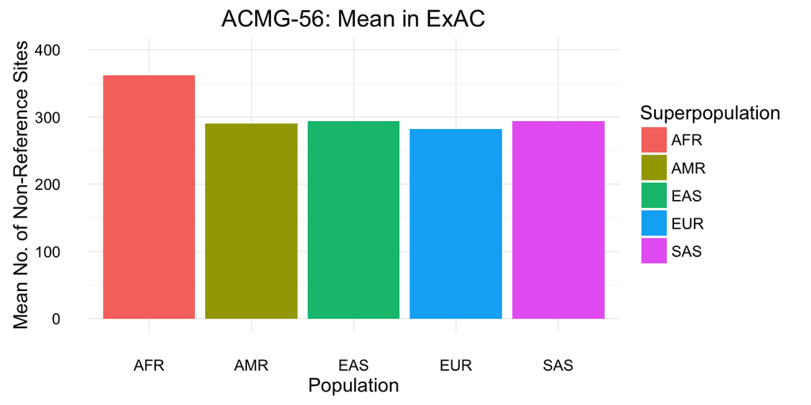

\newpage

## 2.2 Pathogenic Non-Reference Sites

#### 2.2.0.1 For 1000 Genomes and ExAC

This is the same procedure as above, but performed only on the subset of variants that are pathogenic.

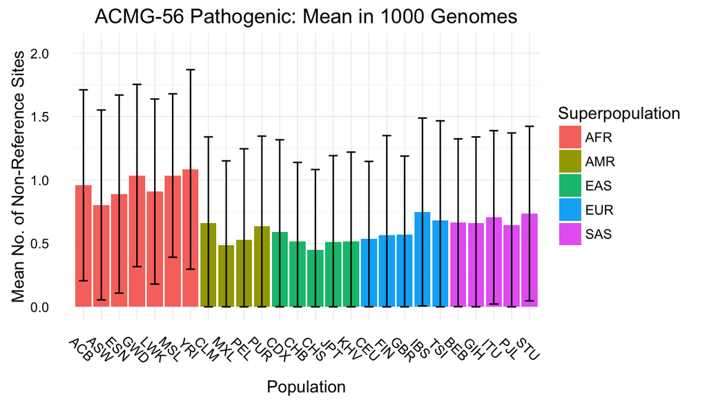

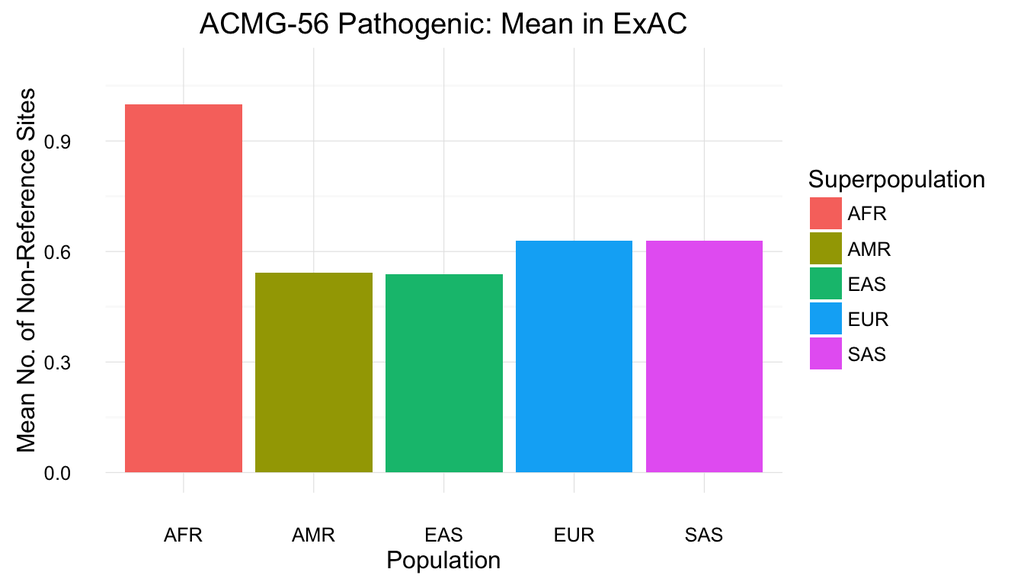

## 2.3 Fraction of Individuals with Pathogenic Sites

#### 2.3.0.1 For 1000 Genomes

We can count up the fraction of individuals with 1+ non-reference site(s) in each population. This is the fraction of individuals who would receive a positive genetic test result in at least 1 of the ACMG-56 genes.

Ex: the genotype of 3 variants in 3 people looks like this:

|  | HG00097 | HG00099 | HG00100 |
| --- | --- | --- | --- |
| **Variant 1** | 0 | 2 | 1 |
| **Variant 2** | 0 | 0 | 1 |
| **Variant 3** | 0 | 0 | 1 |

Count each individual as having a non-reference site (1) or having only reference sites (0):

| HG00097 | HG00099 | HG00100 |
| --- | --- | --- |
| 0 | 1 | 1 |

```
## Mean = 0.667
```

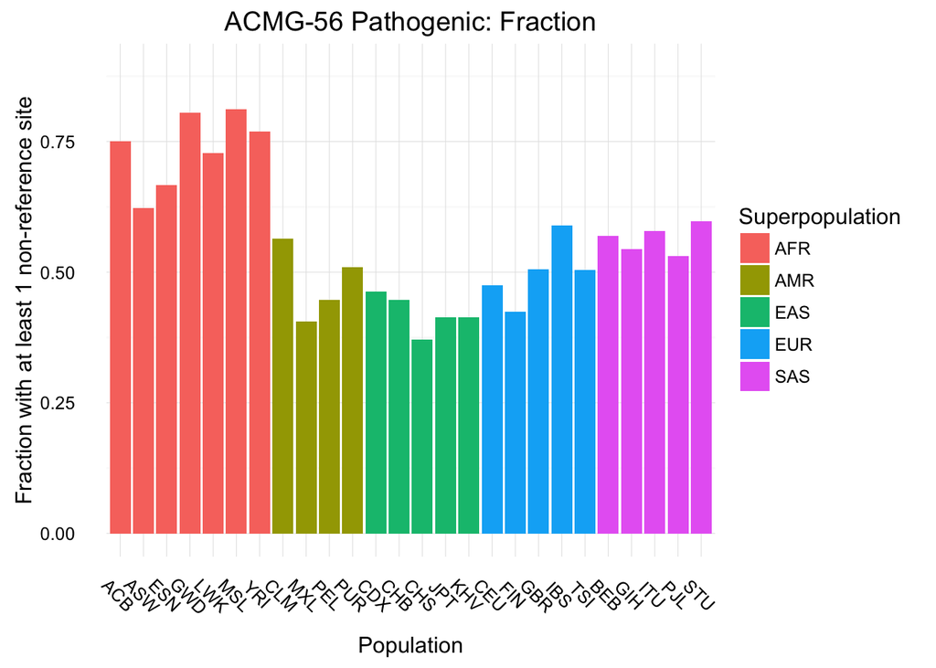

\newpage

#### 2.3.0.2 For ExAC

The probability of having at least 1 non-reference site is $P(X)$, where $X$ indicates a non-reference site at any variant position $v_1$ through $v_n$.

Recall that $P(v_i) = P(v_{i,a} \cup v_{i,b}) = 1-(1-AF(v))^2$ when alleles are independent.

If all alleles are independent, $P(X) = P(\bigcup_{i=1}^n v_i) = 1-\prod_{i=1}^n (1-AF(v_i))^2$

Ex: the allele frequencies of 3 variants across the 5 superpopulations looks like this:

|  | AFR | AMR | EAS | EUR | SAS |
| --- | --- | --- | --- | --- | --- |
| **Variant 1** | 0.1 | 0.2 | 0 | 0 | 0.3 |
| **Variant 2** | 0.2 | 0 | 0.3 | 0 | 0.1 |

The probability of having at least 1 non-reference site at each variant - (0|1) (1|0) or (1|1) is given by $1-(1-AF)^2$.  
Note that this is approximately $2*AF$ when $AF$ is small:

|  | AFR | AMR | EAS | EUR | SAS |
| --- | --- | --- | --- | --- | --- |
| **Variant 1** | 0.19 | 0.36 | 0 | 0 | 0.51 |
| **Variant 2** | 0.36 | 0 | 0.51 | 0 | 0.19 |

The expected (mean) number of non-reference sites is given by $1-\prod (1-AF)^2$.

| AFR | AMR | EAS | EUR | SAS |
| --- | --- | --- | --- | --- |
| 0.4816 | 0.36 | 0.51 | 0 | 0.6031 |

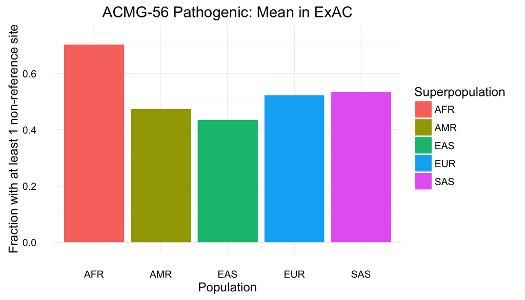

\newpage

## 2.4 Test Statistics for Ancestral Differences

F-statistic/T-statistic: probability that the different groups are sampled from distributions with the same mean.  
These plots are from 4(a) - 1000 Genomes Fraction with 1+ Non-Reference Site, but can be replicated for plots 2(ab) and 3(ab) as well.

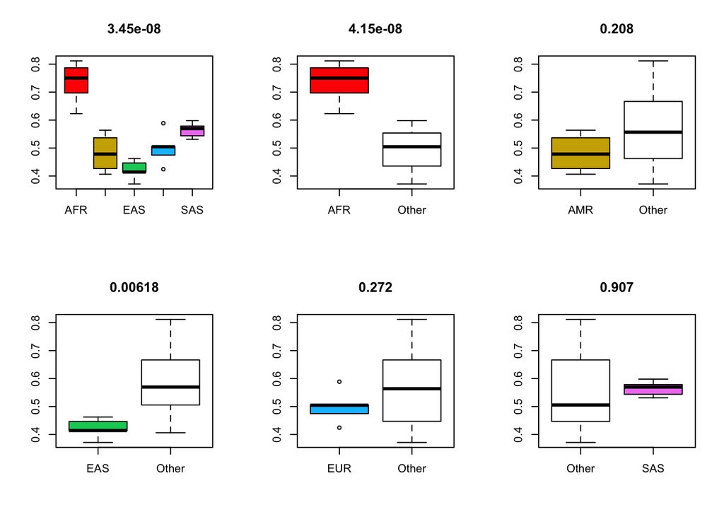

\newpage

## 2.5 Common Pathogenic Variants by Ancestry

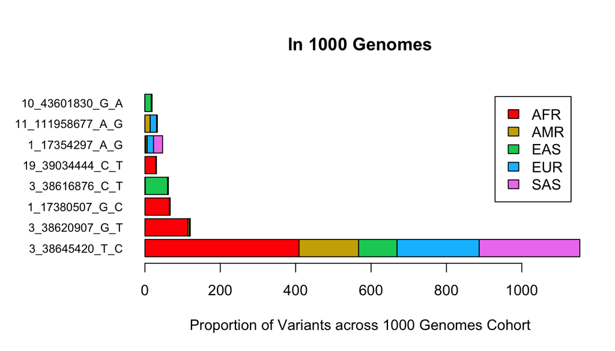

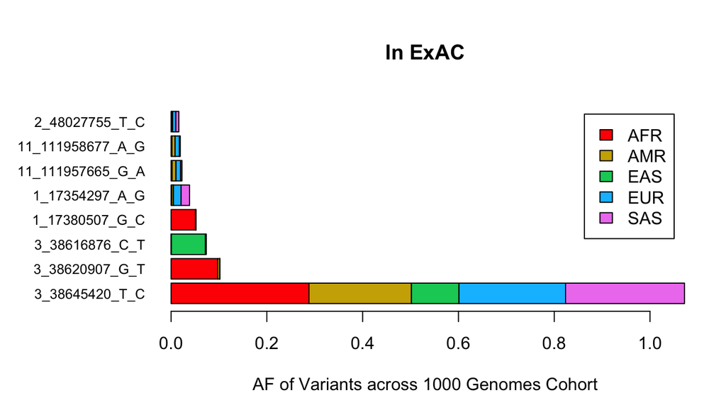

# 3 Penetrance Estimates

Let $V_x$ be the event that an individual has 1 or more variant related to disease $x$,  
and $D_x$ be the event that the individual is later diagnosed with disease $x$.

In this case, we can define the following probabilities:  
1. Prevalence = $P(D_x)$  
2. Allele Frequency = $P(V_x)$  
3. Allelic Heterogeneity = $P(V_x|D_x)$  
4. Penetrance = $P(D_x|V_x)$

By Bayes’ Rule, the penetrance of a variant related to disease $x$ may be defined as:
$$P(D_x|V_x) = \frac{P(D_x)*P(V_x|D_x)}{P(V_x)} = \frac{Prevalence*Allelic-Heteogeneity}{Allele-Frequency}$$

To compute penetrance estimates for each of the diseases related to the ACMG-56 genes, we will use the prevalence data we collected into `Literature_Prevalence_Estimates.csv`, allele frequency data from 1000 Genomes and ExAC, and a broad range of values for allelic heterogeneity.

## 3.2 Import Literature-Based Disease Prevalence Data

Data Collection: 1. Similar disease subtypes were grouped together (e.g., the 8 different types of familial hypertrophic cardiomyopathy), resulting in 30 disease categories across 56 genes.  
2. The search query “[disease name] prevalence” was used to find articles using Google Scholar.  
3. Prevalence estimates were recorded along with URL, journal, region, publication year, sample size, first author, population subset (if applicable), date accessed, and potential issues. Preference was given to studies with PubMed IDs, more citations, and larger sample sizes.

Prevalence was recorded as reported: either a point estimate or a range. Values of varying quality were collected across all diseases.

```
## Table of Literature-Based Estimates of Disease Prevalence 30 x 16 (selected rows/columns):
```

| Gene | Disease | Disease_MIM | Tags |
| --- | --- | --- | --- |
| BRCA1;BRCA2 | Breast-ovarian cancer familial | 604370;612555 | breast;ovarian |
| SCN5A | Brugada syndrome | 601144 | brugada |
| COL3A1 | Ehlers-Danlos syndrome | 130050 | ehler;danlos |
| TP53 | Li-Fraumeni syndrome | 151623 | fraumeni |

Table continues below

| Inverse.Prevalence.1 | Inverse.Prevalence.2 | year | first.author | citations |
| --- | --- | --- | --- | --- |
| 104 | NA | 2013 | NA | NA |
| 10000 | 2000 | 2006 | Antzelevitch | 11 |
| 20000 | NA | 2010 | Malfait | 116 |
| 20000 | 5000 | 1999 | Schneider | 47 |

## 3.3 Distribution of Prevalences

Later, we face the question of how to compute point estimates for penetrance, which requires a point estimate of prevalence. We decided to combine the upper and lower bounds of prevalence ranges using the geometric-mean, or log-average, because the prevalences seem to be distributed most uniformly on a logarithmic-scale.

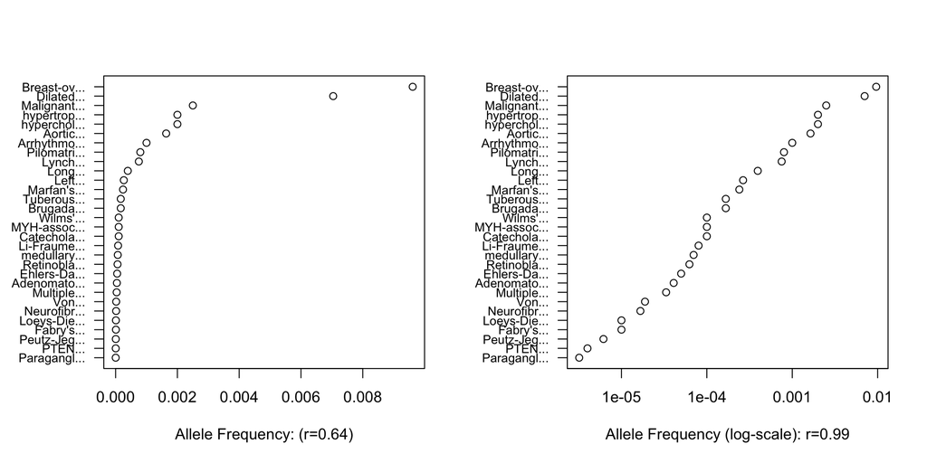

## 3.4 Collect and Aggregate Allele Frequencies at the Disease-Level

We define AF(disease) as the probability of having at least 1 variant associated with the disease.  
The frequencies across the relevant variants can be aggregated in two ways:  
(1) By direct counting, from genotype data in 1000 Genomes.  
(2) AF(disease) = $1-\prod_{variant}(1-AF_{variant})$, from population data in ExAC (assumes independence).

Correlation Table:

|  | COUNT_1000G | CALC_1000G | CALC_EXAC |
| --- | --- | --- | --- |
| **COUNT_1000G** | 1 | 1 | 0.9979 |
| **CALC_1000G** | 1 | 1 | 0.9981 |
| **CALC_EXAC** | 0.9979 | 0.9981 | 1 |

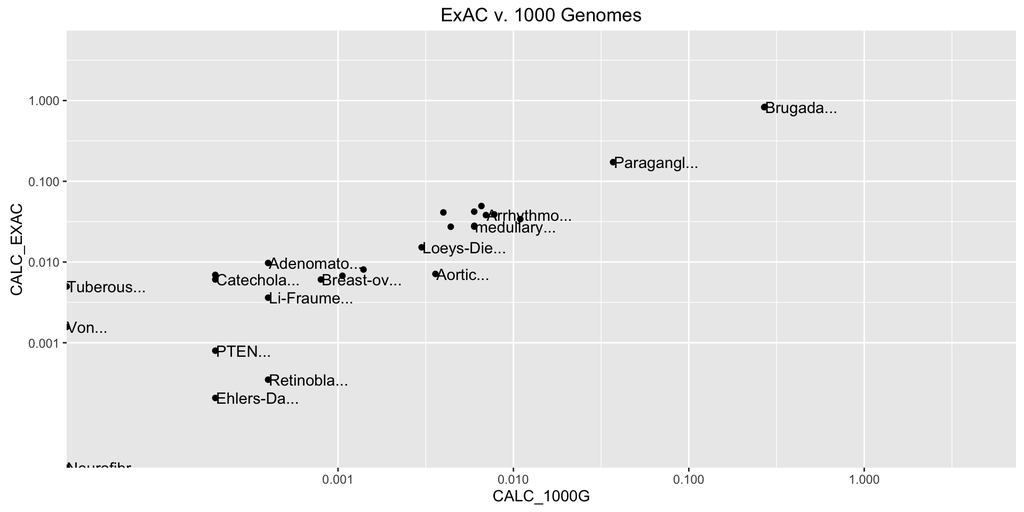

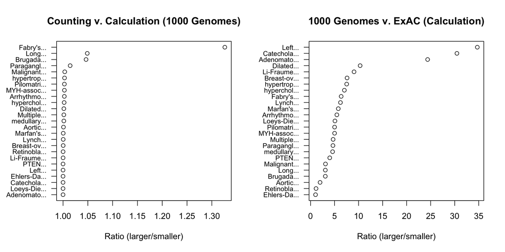

**The median AF(disease) ratio between counting and calculation is: 1.002.**  
**The median AF(disease) ratio between ExAC and 1000 Genomes is: 5.078.**

\newpage

## 3.5 Penetrance as a Function of P(V|D)

The left end of the boxplot indicates P(V|D) = 0.001,  
the bold line in the middle indicates P(V|D) = 0.022,  
the right end of the boxplot indicates P(V|D) = 0.5.

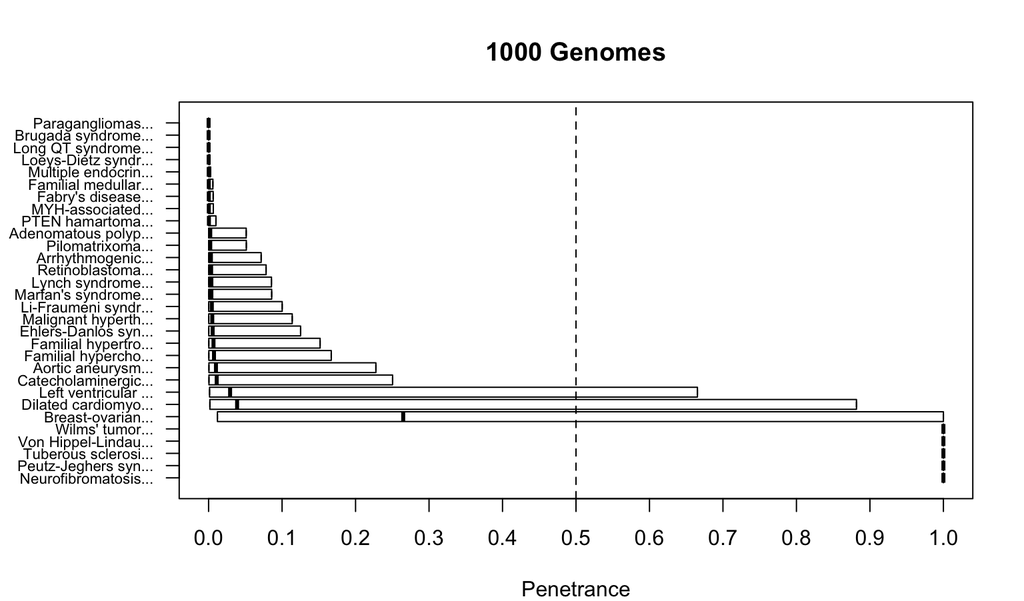

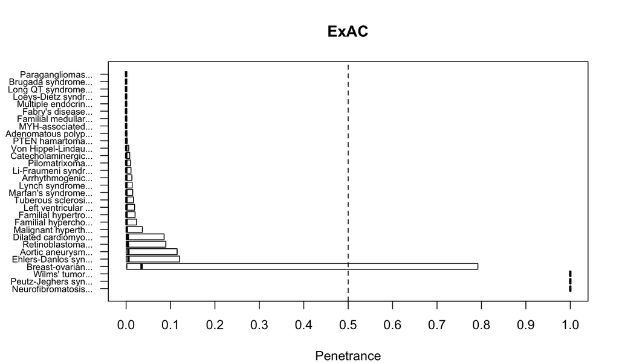

Note: the bold black lines at 1.0 all indicate no allele frequency (disease_AF) data. (Disease_AF = 0 returns “infinite penetrance”, which is capped at 1).

\newpage

## 3.6 Penetrance as a Function of P(D)

| Disease | Prevalence_Ratio |
| --- | --- |
| Retinoblastoma | 1.3 |
| Marfan’s syndrome | 1.5 |
| Lynch syndrome | 3.0 |
| Adenomatous polyposis coli | 3.3 |
| Li-Fraumeni syndrome | 4.0 |
| Paragangliomas | 4.0 |
| Pilomatrixoma | 4.0 |
| Brugada syndrome | 5.0 |
| Peutz-Jeghers syndrome | 12.0 |
| Left ventricular noncompaction | 18.6 |

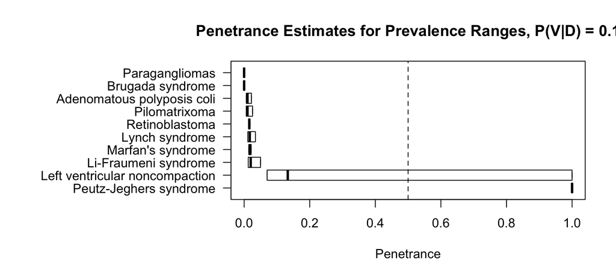

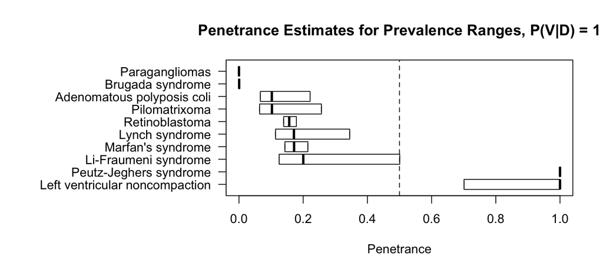

This can only be computed in 10 cases where a prevalence range was given, rather than a point estimate.

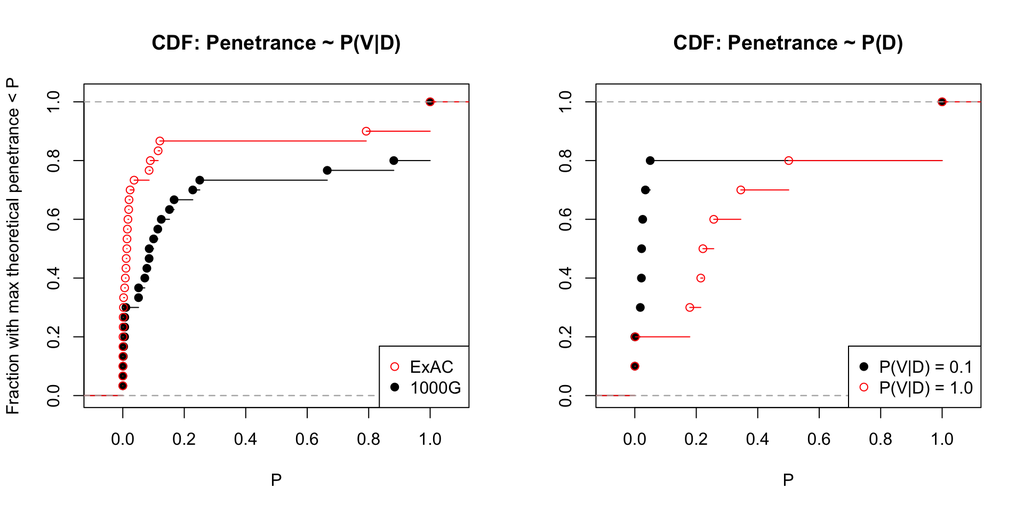

## 3.7 Penetrance ranges given P(D) and P(V|D):

The left end of the boxplot indicates P(D) AND P(V|D) = lower value,  
the bold line in the middle indicates P(D) AND P(V|D) = mean(log(values)),  
the right end of the boxplot indicates P(D) AND P(V|D) = upper value.